# American's TV Interests

By Hosna Hooshyar

## Defining the problem

Some tv series' first episodes or part of them are shown to a randomly selected group of audience before releasing the show. The audience then has to answer questions about what they saw. The aim is to anticipate the shows’ future, improve them if that is necessary and determine some key features, for example, the best day of the week for airing them. The networks rely on this process to save money, resources, and have the best outcome for the show.

This project is aiming to answer these questions:

1. Analyzing the accuracy of these experiments. (How successful they are in predicting the shows’ popularity and success?).
2. Which group of people is the best judges of the quality of tv shows? (Based on gender and education)
3. Predicting people's opinions on the show
4. Predicting if there will be a second season or not

## Data-set

The source of the data is kaggle website: [Link](https://www.kaggle.com/rishidamarla/americans-tv-interests).

The data that is used in this project is collected by surveys. Each survey respondent was randomly shown one of 22 YouTube video previews for a television show debuting in the 2018/2019 season. All of the previews were distributed by the network to promote the show and they varied in length. After watching the video, respondents then provided their opinons on the shows with three features:

1. Interest
2. Uniqueness
3. Relevance

The participants also answer questions about their lives including their gender, their education and etc. It is anticipated that the first limitation of the data is the participants' refusal to answer some of the questions. The other limitation that will affect the prediction models is the number of TV shows in this data which is only 22.

```python
import pandas as pd
import numpy as np
import matplotlib.pyplot as plt
plt.style.use('classic')
%matplotlib inline
import seaborn as sns
import warnings
warnings.filterwarnings('ignore')
```

```python
file_path = '20180904_TV_InterestStudy.csv'
dataFrame = pd.read_csv(file_path)
dataFrame.head(5)
```

|  | start_date | end_date | program | title | birth_year | gender | weekly_tv_viewing | prime_time | prime_time_viewing | binge_watch | ... | separation_state | prev_marriage | parent | hh_structure | hhi | video_view_time | age | demo | generation | race |
| --- | --- | --- | --- | --- | --- | --- | --- | --- | --- | --- | --- | --- | --- | --- | --- | --- | --- | --- | --- | --- | --- |
| 0 | 2018-08-30T13:26:06Z | 2018-08-30T13:29:50Z | 3 | SINGLE PARENTS | 1969 | Men | 0-2 | Watch PT | Recorded | Binged | ... | NaN | NaN | 2 | 3 | Ref | 138.250 | 49 | 45-54 | Xer | White (Non-Hispanic) |
| 1 | 2018-08-30T13:30:56Z | 2018-08-30T13:34:18Z | 5 | GRAND HOTEL | 1969 | Men | 0-2 | No PT | NaN | Never Binged | ... | NaN | NaN | 2 | 3 | Ref | 127.925 | 49 | 45-54 | Xer | White (Non-Hispanic) |
| 2 | 2018-08-30T13:36:28Z | 2018-08-30T13:40:39Z | 22 | I FEEL BAD | 1958 | Women | 10+ | Watch PT | Recorded | Binged | ... | NaN | NaN | 2 | 2 | 100-149K | 141.038 | 60 | 55+ | Boomer | White (Non-Hispanic) |
| 3 | 2018-08-30T13:36:57Z | 2018-08-30T13:41:02Z | 6 | THE FIX | 1972 | Men | 5-Mar | Watch PT | Live | Binged | ... | NaN | 2.0 | 2 | 1 | > 200K | 173.971 | 46 | 45-54 | Xer | Other |
| 4 | 2018-08-30T13:37:13Z | 2018-08-30T13:41:19Z | 3 | SINGLE PARENTS | 1957 | Women | 5-Mar | Watch PT | Live | Binged | ... | NaN | NaN | 2 | 2 | Ref | 163.202 | 61 | 55+ | Boomer | White (Non-Hispanic) |

5 rows × 40 columns

This dataset is named **dataFrame** and includes 40 columns and 2939 rows.

## Cleaning, curation and exploring the data-set

Since our prediction model is as accurate as our data, the dataset needs to be studied carefully. There may be features that should be added, removed, or aggregated, the type of some of them may need to change (i.e. categorical to numerical) or there could be some missing data that must be dealt with. The first step is studying the features:

```python
dataFrame.columns
```

```
Index(['start_date', 'end_date', 'program', 'title', 'birth_year', 'gender',
       'weekly_tv_viewing', 'prime_time', 'prime_time_viewing', 'binge_watch',
       'social_viewing', 'tv_own', 'tv_view_device', 'genres_comedy',
       'genres_drama', 'genres_reality', 'genres_competition', 'genres_news',
       'genres_other', 'genres_other_oe', 'interest', 'uniqueness',
       'relevance', 'zip', 'hispanic', 'ethnicity', 'ethnicity_oe',
       'education', 'married', 'living_situation', 'separation_state',
       'prev_marriage', 'parent', 'hh_structure', 'hhi', 'video_view_time',
       'age', 'demo', 'generation', 'race'],
      dtype='object')
```

Considering the goal of the project some of the above features are unnecessary and should be removed i.e. the date of the beginning and end of the survey (start_date and end_date columns). There are also some redundant features i.e. birth_year and age columns which both offer the same information.

```python
unnecessary_features = ['start_date', 'end_date', 'prime_time', 'prime_time_viewing',
                        'binge_watch', 'social_viewing', 'tv_own', 'tv_view_device', 'zip', 'prev_marriage']
for item in unnecessary_features:
    dataFrame = dataFrame.drop(item, axis=1)
```

```python
redundant_features = ['birth_year', 'hispanic',
                      'ethnicity', 'ethnicity_oe', 'demo']
for item in redundant_features:
    dataFrame = dataFrame.drop(item, axis=1)
```

Looking at the elements of each column and comparing it with the questionnaire (TV_Season_Preview_Questionnaire.txt) is a good way to understand the data better and determine any incorrect values.

```python
dataFrame['title'].value_counts()
```

```
MURPHY BROWN               178
THE FIX                    142
SINGLE PARENTS             139
THE ROOKIE                 138
REL                        136
GRAND HOTEL                135
PROVEN INNOCENT            134
THE KIDS ARE ALRIGHT       134
THE PASSAGE                134
I FEEL BAD                 133
CHARMED                    132
MANIFEST                   131
THE COOL KIDS              131
A MILLION LITTLE THINGS    129
ALL AMERICAN               128
THE NEIGHBORHOOD           128
MAGNUM P.I.                128
GOD FRIENDED ME            128
NEW AMSTERDAM              126
HAPPY TOGETHER             126
WHISKEY CAVALIER           125
FBI                        124
Name: title, dtype: int64
```

*Murphy Brown* show was at its 11th season at the time of this survey, as a result, it is not suitable for this analysis and it needs to be removed:

```python
dataFrame = dataFrame.drop(dataFrame[dataFrame.title == 'MURPHY BROWN'].index)
```

```python
dataFrame['gender'].value_counts()
```

```
Men      1411
Women    1339
NB         11
Name: gender, dtype: int64
```

**NB** stands for Non-binary.

```python
dataFrame['weekly_tv_viewing'].value_counts()
```

```
10+      1740
9-Jun     481
5-Mar     364
0-2       176
Name: weekly_tv_viewing, dtype: int64
```

It is obvious that the values of the *weekly_tv_viewing* column are not correct. This feature shows the number of hours each participant spends watching TV shows on a weekly basis. So values such as 5-Mar are meaningless and should be replaced. Based on the questionnaire file **9-Jun** and **5-Mar** elements should be replaced with **6-9** and **3-5**.

```python
dataFrame['weekly_tv_viewing'] = np.where(
    dataFrame['weekly_tv_viewing'] == '5-Mar', '3-5', dataFrame['weekly_tv_viewing'])
dataFrame['weekly_tv_viewing'] = np.where(
    dataFrame['weekly_tv_viewing'] == '9-Jun', '6-9', dataFrame['weekly_tv_viewing'])
```

```python
dataFrame['genres_comedy'].value_counts()
```

```
1.0    1959
Name: genres_comedy, dtype: int64
```

```python
dataFrame['genres_drama'].value_counts()
```

```
1.0    1855
Name: genres_drama, dtype: int64
```

```python
dataFrame['genres_reality'].value_counts()
```

```
1.0    993
Name: genres_reality, dtype: int64
```

```python
dataFrame['genres_competition'].value_counts()
```

```
1.0    839
Name: genres_competition, dtype: int64
```

```python
dataFrame['genres_news'].value_counts()
```

```
1.0    1126
Name: genres_news, dtype: int64
```

```python
dataFrame['genres_other'].value_counts()
```

```
1.0    405
Name: genres_other, dtype: int64
```

```python
dataFrame['genres_other_oe'].value_counts()
```

```
Sports                                                                   28
sports                                                                   25
Horror                                                                   12
Action                                                                   11
Documentary                                                               9
                                                                         ..
Classics                                                                  1
Discovery                                                                 1
Home improvement                                                          1
fantasy                                                                   1
Documentaries, comedies for thinking people (black-ish, Rick & Morty)     1
Name: genres_other_oe, Length: 164, dtype: int64
```

*genres_other_oe* is about the genres that the participants like but were not mentioned in the survey. As you can see some of these genres have only one vote.

```python
dataFrame['interest'].value_counts()
```

```
 1    823
 2    810
 0    598
-1    328
-2    202
Name: interest, dtype: int64
```

```python
dataFrame['uniqueness'].value_counts()
```

```
 1    1208
 2     785
 0     422
-1     244
-2     102
Name: uniqueness, dtype: int64
```

```python
dataFrame['relevance'].value_counts()
```

```
 1    887
 0    780
 2    479
-1    332
-2    283
Name: relevance, dtype: int64
```

```python
dataFrame['education'].value_counts()
```

```
College         943
Some College    680
HS              470
Grad            431
Vocational      110
Some Grad        76
Some HS          45
Ref               6
Name: education, dtype: int64
```

```python
dataFrame['married'].value_counts()
```

```
1    1448
2    1313
Name: married, dtype: int64
```

1 means the participant was married at the time of survey and 2 means she/he was not.

```python
dataFrame['living_situation'].value_counts()
```

```
1.0    1407
2.0      41
Name: living_situation, dtype: int64
```

1 means that the married participant and her/his partner were living together at the time of the survey and 2 means they were not.

```python
dataFrame['separation_state'].value_counts()
```

```
2.0    30
1.0    11
Name: separation_state, dtype: int64
```

1 means that the married participant who did not live with her/his partner, considered the separation temporary, and 2 means permanent.

```python
dataFrame['parent'].value_counts()
```

```
2    1788
1     973
Name: parent, dtype: int64
```

1 means that the participant is the parent or guardian of any children under 18 years of age and 2 means that she/he is not.

```python
dataFrame['hh_structure'].value_counts()
```

```
2    1472
1     678
3     394
4     173
5      44
Name: hh_structure, dtype: int64
```

*hh_structure* shows how many adults, age 18 and over, lived in the participant's household (including the participant).

```python
dataFrame['hhi'].value_counts()
```

```
50-99K      983
20-49K      788
100-149K    405
< 20K       278
Ref         131
150-200K    106
> 200K       70
Name: hhi, dtype: int64
```

```python
dataFrame['video_view_time'].value_counts()
```

```
195.325     2
170.423     2
209.437     2
164.870     2
173.739     2
           ..
203.824     1
130.086     1
2857.111    1
392.009     1
159.000     1
Name: video_view_time, Length: 2747, dtype: int64
```

```python
dataFrame['generation'].value_counts()
```

```
Xer           982
Millennial    975
Boomer        730
Silent         45
Gen Z          29
Name: generation, dtype: int64
```

This picture shows the age and birthdate of each value of the generation column. (Source of the image).)

[figure not shown]

```python
dataFrame['race'].value_counts()
```

```
White (Non-Hispanic)    2072
Hispanic                 244
Other                    205
Black (Non-Hispanic)     189
DK/Ref                    35
Name: race, dtype: int64
```

```python
dataFrame_info = dataFrame.info()
```

```
<class 'pandas.core.frame.DataFrame'>
Int64Index: 2761 entries, 0 to 2760
Data columns (total 25 columns):
 #   Column              Non-Null Count  Dtype
---  ------              --------------  -----
 0   program             2761 non-null   int64
 1   title               2761 non-null   object
 2   gender              2761 non-null   object
 3   weekly_tv_viewing   2761 non-null   object
 4   genres_comedy       1959 non-null   float64
 5   genres_drama        1855 non-null   float64
 6   genres_reality      993 non-null    float64
 7   genres_competition  839 non-null    float64
 8   genres_news         1126 non-null   float64
 9   genres_other        405 non-null    float64
```

[output cut: 17 more lines]

The code above gives us information about each column, its values, and type. It also indicates that some of the columns have missing values. The problem is, although it tells us about null missing values, it doesn't give us any information about the values which are not available because the participant chose **"Prefer not to say"** option. Comparing the values of columns with the questionnaire indicates that this option is displayed by **Ref** in the data frame. **Ref** elements will be replaced by null.

```python
dataFrame['education'] = np.where(
    dataFrame['education'] == 'Ref', None, dataFrame['education'])
dataFrame['hhi'] = np.where(dataFrame['hhi'] == 'Ref', None, dataFrame['hhi'])
dataFrame['race'] = np.where(
    dataFrame['race'] == 'DK/Ref', None, dataFrame['race'])
```

```python
missing_data = pd.DataFrame(dataFrame.isna().sum(), columns=[
                            'number of missing values'])
missing_data['Percentage of missing values'] = missing_data['number of missing values'].aggregate(
    lambda x: (x/2939)*100)
missing_data
```

|  | number of missing values | Percentage of missing values |
| --- | --- | --- |
| program | 0 | 0.000000 |
| title | 0 | 0.000000 |
| gender | 0 | 0.000000 |
| weekly_tv_viewing | 0 | 0.000000 |
| genres_comedy | 802 | 27.288193 |
| genres_drama | 906 | 30.826812 |
| genres_reality | 1768 | 60.156516 |
| genres_competition | 1922 | 65.396393 |
| genres_news | 1635 | 55.631167 |
| genres_other | 2356 | 80.163321 |
| genres_other_oe | 2451 | 83.395713 |
| interest | 0 | 0.000000 |
| uniqueness | 0 | 0.000000 |
| relevance | 0 | 0.000000 |
| education | 6 | 0.204151 |
| married | 0 | 0.000000 |
| living_situation | 1313 | 44.675060 |
| separation_state | 2720 | 92.548486 |
| parent | 0 | 0.000000 |
| hh_structure | 0 | 0.000000 |
| hhi | 131 | 4.457298 |
| video_view_time | 0 | 0.000000 |
| age | 0 | 0.000000 |
| generation | 0 | 0.000000 |
| race | 51 | 1.735284 |

The features of the list named **missing** belong to the first group of missing data.

```python
missing = ['living_situation', 'separation_state', 'genres_other_oe']
for item in missing:
    dataFrame = dataFrame.drop(item, axis=1)
```

To deal with the second group of missing data, a column named *favorite_genre* will be added to the current data frame.

```python
dataFrame['favorite_genre'] = ''
```

```python
dataFrame['favorite_genre'] = np.where(
    dataFrame['genres_comedy'] == 1, 'comedy', dataFrame['favorite_genre'])
dataFrame['favorite_genre'] = np.where(
    dataFrame['genres_drama'] == 1, 'drama', dataFrame['favorite_genre'])
dataFrame['favorite_genre'] = np.where(
    dataFrame['genres_reality'] == 1, 'reality', dataFrame['favorite_genre'])
dataFrame['favorite_genre'] = np.where(
    dataFrame['genres_competition'] == 1, 'competition', dataFrame['favorite_genre'])
dataFrame['favorite_genre'] = np.where(
    dataFrame['genres_news'] == 1, 'news', dataFrame['favorite_genre'])
dataFrame['favorite_genre'] = np.where(
    dataFrame['genres_other'] == 1, 'other', dataFrame['favorite_genre'])
```

*favorite_genre* indicates every participant's favorite genre, as a result, the columns below are not needed anymore:

```python
unnecessary_features_2 = ['genres_comedy', 'genres_drama', 'genres_reality', 'genres_competition',
                          'genres_news', 'genres_other']
for item in unnecessary_features_2:
    dataFrame = dataFrame.drop(item, axis=1)
```

```python
dataFrame.head(5)
```

|  | program | title | gender | weekly_tv_viewing | interest | uniqueness | relevance | education | married | parent | hh_structure | hhi | video_view_time | age | generation | race | favorite_genre |
| --- | --- | --- | --- | --- | --- | --- | --- | --- | --- | --- | --- | --- | --- | --- | --- | --- | --- |
| 0 | 3 | SINGLE PARENTS | Men | 0-2 | 0 | 0 | -1 | Grad | 1 | 2 | 3 | None | 138.250 | 49 | Xer | White (Non-Hispanic) | news |
| 1 | 5 | GRAND HOTEL | Men | 0-2 | -1 | -1 | -2 | Grad | 1 | 2 | 3 | None | 127.925 | 49 | Xer | White (Non-Hispanic) | comedy |
| 2 | 22 | I FEEL BAD | Women | 10+ | 0 | 1 | 1 | Grad | 1 | 2 | 2 | 100-149K | 141.038 | 60 | Boomer | White (Non-Hispanic) | news |
| 3 | 6 | THE FIX | Men | 3-5 | 2 | 2 | 2 | Some HS | 2 | 2 | 1 | > 200K | 173.971 | 46 | Xer | Other | news |
| 4 | 3 | SINGLE PARENTS | Women | 3-5 | -2 | 0 | -2 | Some Grad | 1 | 2 | 2 | None | 163.202 | 61 | Boomer | White (Non-Hispanic) | drama |

To estimate the success of the shows three features will be collected and added to data to measure the success of each show:

1. Renewal for the second season
2. Show’s rating in IMDb, given by the audience
3. Show’s rating in Rotten tomatoes, given by critics

To do so the name of the shows are needed that are already obtained.

The second data-set, named **TV Interest Study-success features**, is collected by visiting each movie's page on [IMDb](https://www.imdb.com/) and [Rotten Tomatoes](https://www.rottentomatoes.com/) websites. It includes the ratings on those websites and whether the show got a second season or not.

```python
file_path_2 = 'TV Interest Study-success features.csv'
features_of_success = pd.read_csv(file_path_2)
features_of_success.head(5)
```

|  | title | IMDb rating | rotten tomatoes | Season 2 |
| --- | --- | --- | --- | --- |
| 0 | THE FIX | 6.5 | 56.0 | no |
| 1 | SINGLE PARENTS | 7.1 | 75.0 | yes |
| 2 | THE ROOKIE | 8.1 | 68.0 | yes |
| 3 | REL | 4.2 | 44.0 | no |
| 4 | GRAND HOTEL | 7.0 | 74.0 | no |

Using the code below, the two data-sets will merge.

```python
dataFrame = pd.merge(dataFrame, features_of_success, on='title')
dataFrame
```

|  | program | title | gender | weekly_tv_viewing | interest | uniqueness | relevance | education | married | parent | hh_structure | hhi | video_view_time | age | generation | race | favorite_genre | IMDb rating | rotten tomatoes | Season 2 |
| --- | --- | --- | --- | --- | --- | --- | --- | --- | --- | --- | --- | --- | --- | --- | --- | --- | --- | --- | --- | --- |
| 0 | 3 | SINGLE PARENTS | Men | 0-2 | 0 | 0 | -1 | Grad | 1 | 2 | 3 | None | 138.250 | 49 | Xer | White (Non-Hispanic) | news | 7.1 | 75.0 | yes |
| 1 | 3 | SINGLE PARENTS | Women | 3-5 | -2 | 0 | -2 | Some Grad | 1 | 2 | 2 | None | 163.202 | 61 | Boomer | White (Non-Hispanic) | drama | 7.1 | 75.0 | yes |
| 2 | 3 | SINGLE PARENTS | Women | 3-5 | 1 | 1 | 2 | College | 1 | 1 | 2 | 50-99K | 175.908 | 28 | Millennial | White (Non-Hispanic) | competition | 7.1 | 75.0 | yes |
| 3 | 3 | SINGLE PARENTS | Women | 6-9 | 1 | 1 | 1 | Grad | 1 | 1 | 2 | 150-200K | 165.774 | 43 | Xer | White (Non-Hispanic) | reality | 7.1 | 75.0 | yes |
| 4 | 3 | SINGLE PARENTS | Men | 6-9 | -1 | -1 | -1 | College | 2 | 2 | 1 | 100-149K | 136.732 | 22 | Millennial | Hispanic | news | 7.1 | 75.0 | yes |
| ... | ... | ... | ... | ... | ... | ... | ... | ... | ... | ... | ... | ... | ... | ... | ... | ... | ... | ... | ... | ... |
| 2098 | 21 | NEW AMSTERDAM | Men | 10+ | 1 | 2 | 1 | HS | 2 | 2 | 1 | 20-49K | 162.825 | 19 | Millennial | White (Non-Hispanic) | other | 8.1 | 34.0 | yes |
| 2099 | 21 | NEW AMSTERDAM | Men | 10+ | 0 | 0 | 0 | Some College | 1 | 2 | 4 | 50-99K | 157.936 | 46 | Xer | Hispanic | reality | 8.1 | 34.0 | yes |
| 2100 | 21 | NEW AMSTERDAM | Men | 6-9 | 2 | 1 | 1 | College | 1 | 2 | 5 | 50-99K | 187.305 | 54 | Boomer | White (Non-Hispanic) | other | 8.1 | 34.0 | yes |
| 2101 | 21 | NEW AMSTERDAM | Men | 6-9 | 2 | 2 | 1 | Vocational | 2 | 2 | 3 | 20-49K | 189.066 | 45 | Xer | White (Non-Hispanic) | news | 8.1 | 34.0 | yes |
| 2102 | 21 | NEW AMSTERDAM | Women | 10+ | 2 | 2 | 0 | HS | 1 | 1 | 3 | 50-99K | 199.190 | 51 | Xer | White (Non-Hispanic) | other | 8.1 | 34.0 | yes |

2103 rows × 20 columns

# Analyze

### How accurate is the survey? (How successful is it in predicting the shows’ future?)

To answer this question the success features (IMDb rating, rotten tomatoes, Season 2) and the factors related to participants' opinions on tv shows (interest, uniqueness, relevance) will be compared. But first, the numerical factors should be put in the same range.

1. IMDb rating = [1:10]
2. Rotten tomatoes = [0:100]
3. interest, uniqueness, and relevance = -2,-1,0,1,2

IMDb and Rotten tomatoes ratings will be converted to [-2:2] range.After that, the data-set will be named **dataFrame_2**

```python
dataFrame_2 = dataFrame
dataFrame_2['IMDb rating'] = dataFrame_2['IMDb rating'].aggregate(
    lambda x: ((x-1)/(10-1))*(4)-2)
dataFrame_2['rotten tomatoes'] = dataFrame_2['rotten tomatoes'].aggregate(
    lambda x: ((x-0)/(100-0))*(4)-2)
```

```python
dataFrame_2.head(5)
```

|  | program | title | gender | weekly_tv_viewing | interest | uniqueness | relevance | education | married | parent | hh_structure | hhi | video_view_time | age | generation | race | favorite_genre | IMDb rating | rotten tomatoes | Season 2 |
| --- | --- | --- | --- | --- | --- | --- | --- | --- | --- | --- | --- | --- | --- | --- | --- | --- | --- | --- | --- | --- |
| 0 | 3 | SINGLE PARENTS | Men | 0-2 | 0 | 0 | -1 | Grad | 1 | 2 | 3 | None | 138.250 | 49 | Xer | White (Non-Hispanic) | news | 0.711111 | 1.0 | yes |
| 1 | 3 | SINGLE PARENTS | Women | 3-5 | -2 | 0 | -2 | Some Grad | 1 | 2 | 2 | None | 163.202 | 61 | Boomer | White (Non-Hispanic) | drama | 0.711111 | 1.0 | yes |
| 2 | 3 | SINGLE PARENTS | Women | 3-5 | 1 | 1 | 2 | College | 1 | 1 | 2 | 50-99K | 175.908 | 28 | Millennial | White (Non-Hispanic) | competition | 0.711111 | 1.0 | yes |
| 3 | 3 | SINGLE PARENTS | Women | 6-9 | 1 | 1 | 1 | Grad | 1 | 1 | 2 | 150-200K | 165.774 | 43 | Xer | White (Non-Hispanic) | reality | 0.711111 | 1.0 | yes |
| 4 | 3 | SINGLE PARENTS | Men | 6-9 | -1 | -1 | -1 | College | 2 | 2 | 1 | 100-149K | 136.732 | 22 | Millennial | Hispanic | news | 0.711111 | 1.0 | yes |

The focus of this step will be on the success features and the features that predicted it. As a result a new data frame, named **dataFrame_success** will be defined and only includes the columns that are needed for this step.

```python
dataFrame_success = dataFrame_2[['title', 'interest', 'uniqueness',
                           'relevance', 'IMDb rating', 'rotten tomatoes', 'Season 2']]
dataFrame_success
```

|  | title | interest | uniqueness | relevance | IMDb rating | rotten tomatoes | Season 2 |
| --- | --- | --- | --- | --- | --- | --- | --- |
| 0 | SINGLE PARENTS | 0 | 0 | -1 | 0.711111 | 1.00 | yes |
| 1 | SINGLE PARENTS | -2 | 0 | -2 | 0.711111 | 1.00 | yes |
| 2 | SINGLE PARENTS | 1 | 1 | 2 | 0.711111 | 1.00 | yes |
| 3 | SINGLE PARENTS | 1 | 1 | 1 | 0.711111 | 1.00 | yes |
| 4 | SINGLE PARENTS | -1 | -1 | -1 | 0.711111 | 1.00 | yes |
| ... | ... | ... | ... | ... | ... | ... | ... |
| 2098 | NEW AMSTERDAM | 1 | 2 | 1 | 1.155556 | -0.64 | yes |
| 2099 | NEW AMSTERDAM | 0 | 0 | 0 | 1.155556 | -0.64 | yes |
| 2100 | NEW AMSTERDAM | 2 | 1 | 1 | 1.155556 | -0.64 | yes |
| 2101 | NEW AMSTERDAM | 2 | 2 | 1 | 1.155556 | -0.64 | yes |
| 2102 | NEW AMSTERDAM | 2 | 2 | 0 | 1.155556 | -0.64 | yes |

2103 rows × 7 columns

```python
dataFrame_success.describe()
```

|  | interest | uniqueness | relevance | IMDb rating | rotten tomatoes |
| --- | --- | --- | --- | --- | --- |
| count | 2103.000000 | 2103.000000 | 2103.000000 | 2103.000000 | 2103.000000 |
| mean | 0.584403 | 0.848787 | 0.343795 | 0.607513 | 0.175490 |
| std | 1.237837 | 1.051915 | 1.199912 | 0.426216 | 0.924876 |
| min | -2.000000 | -2.000000 | -2.000000 | -0.400000 | -1.732000 |
| 25% | 0.000000 | 0.000000 | 0.000000 | 0.355556 | -0.760000 |
| 50% | 1.000000 | 1.000000 | 0.000000 | 0.666667 | 0.360000 |
| 75% | 2.000000 | 2.000000 | 1.000000 | 1.022222 | 0.960000 |
| max | 2.000000 | 2.000000 | 2.000000 | 1.155556 | 1.840000 |

This table shows statistical properties of **dataFrame_success**. The mean of Interest variable is very close to the mean of IMDb rating, indicating that the survey can be considered successful in predicting the audience's interest in the shows based on short premieres that were shown to participants. To assess this conclusion plots and mathematical operations will be used.

[figure not shown]

```python
dataFrame_success.groupby('title')['interest', 'IMDb rating', 'rotten tomatoes'].mean(
).plot(kind='bar', title='Level of interest', figsize=(15, 8),width = 0.6)
plt.show()
```

[figure not shown]

```python
dataFrame_success.groupby('title')['uniqueness', 'IMDb rating', 'rotten tomatoes'].mean(
).plot(kind='bar', title='Level of uniqueness', figsize=(15, 8), width=0.6)
plt.show()
```

[figure not shown]

```python
dataFrame_success.groupby('title')['relevance', 'IMDb rating', 'rotten tomatoes'].mean(
).plot(kind='bar', title='Level of relevance', figsize=(15, 8), width=0.6)
plt.show()
```

These three plots (Level of relevance, Level of uniqueness, Level of interest) prove that although IMDb ratings of TV shows are close to what the survey predicted in some cases, Rotten tomatoes ratings are very different.

```python
for i in ['interest', 'uniqueness', 'relevance']:
    for j in ['IMDb rating', 'rotten tomatoes']:
        k = 0
        difference_percentage = ((dataFrame_success.groupby('title')[i].mean(
        ) - dataFrame_success.groupby('title')[j].mean())/dataFrame_success.groupby('title')[i].mean())*100
        print("Percentage difference between %s and %s is: \n %s" %
              (i, j, difference_percentage))
        for g in range(0, len(difference_percentage)-1):
            if np.abs(difference_percentage[g]) < 30:
                k += 1
            else:
                continue
        print("The number of shows with less than thirty percent difference between %s and %s is %d." % (i, j, k))
        print('')
```

```
Percentage difference between interest and IMDb rating is:
 title
A MILLION LITTLE THINGS   -105.373134
ALL AMERICAN               -69.129129
CHARMED                    260.000000
GOD FRIENDED ME             23.418803
GRAND HOTEL               -542.857143
HAPPY TOGETHER              74.153846
I FEEL BAD                  53.638344
MAGNUM P.I.                 78.666667
NEW AMSTERDAM               -4.748201
PROVEN INNOCENT             29.934641
SINGLE PARENTS             -56.895944
THE COOL KIDS                6.093190
THE KIDS ARE ALRIGHT       -61.150327
THE NEIGHBORHOOD            24.148148
THE PASSAGE                -11.666667
THE ROOKIE                 -32.888889
dtype: float64
The number of shows with less than thirty percent difference between interest and IMDb rating is 6.

Percentage difference between interest and rotten tomatoes is:
 title
A MILLION LITTLE THINGS     76.895522
ALL AMERICAN              -218.270270
CHARMED                    792.800000
GOD FRIENDED ME             55.692308
GRAND HOTEL               -825.714286
HAPPY TOGETHER              76.738462
I FEEL BAD                 298.196078
MAGNUM P.I.                 55.200000
NEW AMSTERDAM              158.014388
PROVEN INNOCENT            238.729412
SINGLE PARENTS            -120.634921
THE COOL KIDS               15.483871
THE KIDS ARE ALRIGHT      -101.788235
THE NEIGHBORHOOD           321.866667
THE PASSAGE                 33.000000
THE ROOKIE                  17.200000
dtype: float64
```

[output cut: 70 more lines]

```
GOD FRIENDED ME               43.804878
GRAND HOTEL                 1720.000000
HAPPY TOGETHER                46.000000
I FEEL BAD                   324.622222
MAGNUM P.I.                    5.684211
NEW AMSTERDAM                183.134021
PROVEN INNOCENT              270.898551
SINGLE PARENTS            -13800.000000
THE COOL KIDS                -87.142857
THE KIDS ARE ALRIGHT        -109.170732
THE NEIGHBORHOOD             654.666667
THE PASSAGE                  -14.857143
THE ROOKIE                   -62.885246
dtype: float64
The number of shows with less than thirty percent difference between relevance and rotten tomatoes is 2.
```

The accuracy of the survey can be assessed from another aspect which is renewal for second season.

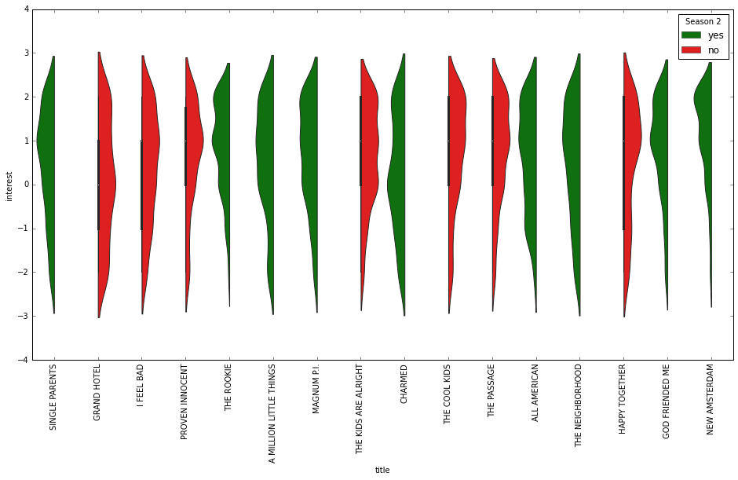

```python
plt.figure(figsize=(16, 8))
plt.xticks(rotation=90)
sns.violinplot(x='title', y='interest', data=dataFrame_success,
               hue='Season 2', split=True, palette=['g', 'r']);
```

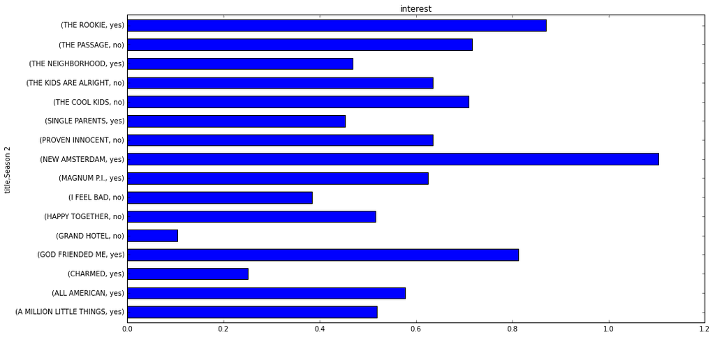

```python
dataFrame_success.groupby(['title','Season 2'])['interest'].mean(
).plot(kind='barh', title='interest', figsize=(15, 8), width=0.6)
plt.show()
```

```python
success_mean = dataFrame_success.groupby(['title','Season 2'])['interest'].mean()
success_mean.sort_values()
```

```
title                    Season 2
GRAND HOTEL              no          0.103704
CHARMED                  yes         0.250000
I FEEL BAD               no          0.383459
SINGLE PARENTS           yes         0.453237
THE NEIGHBORHOOD         yes         0.468750
HAPPY TOGETHER           no          0.515873
A MILLION LITTLE THINGS  yes         0.519380
ALL AMERICAN             yes         0.578125
MAGNUM P.I.              yes         0.625000
PROVEN INNOCENT          no          0.634328
THE KIDS ARE ALRIGHT     no          0.634328
THE COOL KIDS            no          0.709924
THE PASSAGE              no          0.716418
GOD FRIENDED ME          yes         0.812500
THE ROOKIE               yes         0.869565
NEW AMSTERDAM            yes         1.103175
Name: interest, dtype: float64
```

### Which group of participants offered a more accurate prediction?

#### Based on gender

The participants of this survey belong to three gender groups: Female, male, and non-binary. Only 11 people are in the non-binary category (while over one thousand people are in the other two categories), the rows related to this gender will be removed due to the fact that there is not enough data to compare. The new dataframe is called **dataFrame_gender**.

```python
dataFrame_gender = dataFrame_2.drop(dataFrame[dataFrame.gender == 'NB'].index);
```

```python
dataFrame_gender_w = dataFrame_gender.drop(dataFrame[dataFrame.gender == 'Men'].index);
dataFrame_gender_m = dataFrame_gender.drop(dataFrame[dataFrame.gender == 'Women'].index);
```

```python
title_dict = dataFrame_gender['title'].value_counts()
title_list = title_dict.keys()
```

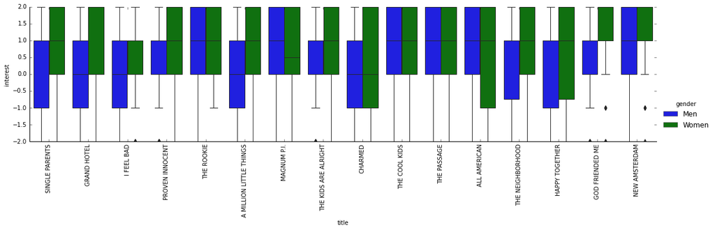

```python
sns.catplot(
    data=dataFrame_gender,
    x='title',
    y='interest',
    hue='gender',
    kind='box',
    height=4,
    aspect=4)
plt.xticks(rotation=90);
```

If boxes, which show the interquartile range (IQR), are compared to each other, it can be seen that the boxes indicating men's interest are located lower than the boxes indicating women's interest. It shows that in most cases the majority of men show less interest in TV series than women.

To see which group predictions is more accurate:

[figure not shown]

```python
barWidth = 0.25

bars1 = dataFrame_gender_w.groupby(['title'])['interest'].mean()
bars2 = dataFrame_gender_m.groupby(['title'])['interest'].mean()
bars3 = dataFrame_gender.groupby(['title'])['IMDb rating'].mean()

r1 = np.arange(len(bars1))
r2 = [x + barWidth for x in r1]
r3 = [x + barWidth for x in r2]

plt.figure(figsize=(13, 8))

plt.bar(r1, bars1, color='red', width=barWidth,
        edgecolor='white', label='Interst_w')
plt.bar(r2, bars2, color='black', width=barWidth,
        edgecolor='white', label='Interst_m')
plt.bar(r3, bars3, color='blue', width=barWidth,
        edgecolor='white', label='IMDb rating')

plt.xlabel('Title of the show', fontweight='bold')
plt.xticks([r + barWidth for r in range(len(bars1))], title_list)
plt.xticks(rotation=90)
plt.legend(loc=(1.1, 0.5))
plt.show()
```

```python
for i in ['interest', 'uniqueness', 'relevance']:
    for j in ['IMDb rating', 'rotten tomatoes']:
        difference_percentage = ((dataFrame_gender.groupby('gender')[i].mean(
        ) - dataFrame_gender.groupby('gender')[j].mean())/dataFrame_gender.groupby('gender')[i].mean())*100
        print("Percentage difference between %s and %s is: \n %s" %
              (i, j, difference_percentage))
        print('')
```

```
Percentage difference between interest and IMDb rating is:
 gender
Men     -36.061885
Women    17.142857
dtype: float64

Percentage difference between interest and rotten tomatoes is:
 gender
Men      60.405063
Women    76.188360
dtype: float64

Percentage difference between uniqueness and IMDb rating is:
 gender
Men      21.349593
Women    34.750000
dtype: float64

Percentage difference between uniqueness and rotten tomatoes is:
 gender
Men      77.112195
Women    81.248333
dtype: float64

Percentage difference between relevance and IMDb rating is:
 gender
Men     -144.292929
Women    -38.278146
dtype: float64

Percentage difference between relevance and rotten tomatoes is:
 gender
Men      28.909091
Women    60.261369
dtype: float64
```

#### Based on education

Based on **Cleaning, curation, and exploring the data-set** step, the education feature has six missing values. These values can be removed or replaced. Here we choose the latter.

```python
dataFrame_2['education'].value_counts()
```

```
College         734
Some College    517
HS              349
Grad            315
Vocational       88
Some Grad        61
Some HS          35
Name: education, dtype: int64
```

Since the majority of participants are college graduates, the missing data will be filled with this educational level and name the new data frame **dataFrame_education**.

```python
dataFrame_education = dataFrame_2.fillna('College')
```

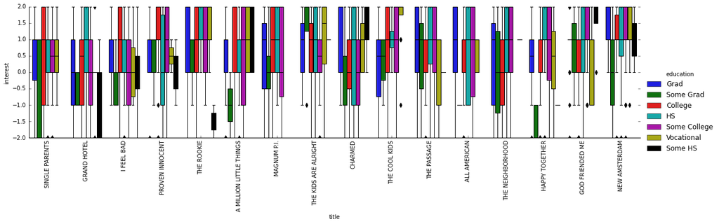

```python
sns.catplot(
    data=dataFrame_education,
    x='title',
    y='interest',
    hue='education',
    kind='box',
    height=4, # make the plot 5 units high
    aspect=4)
plt.xticks(rotation=90);
```

At first look, it seems that people belong to **Some College** category were more interested in upcoming TV shows than the others but the problem is the number of people in each category varies drastically. Some of the shows were not watched by every education group simply because there were not enough participants from some categories such as **Some HS**. To discover which group's opinion is closer to what happens in the future, more data from each group is needed.

To see the percentage difference between the interest and success features:

```python
for j in ['IMDb rating', 'rotten tomatoes']:
    difference_percentage = ((dataFrame_education.groupby('education')['interest'].mean(
    ) - dataFrame_education.groupby('education')[j].mean())/dataFrame_education.groupby('education')['interest'].mean())*100
    print("Percentage difference between %s and %s is: \n %s" %
          (i, j, difference_percentage))
    print('')
```

```
Percentage difference between relevance and IMDb rating is:
 education
College          -4.507636
Grad             -7.283237
HS               18.392784
Some College    -11.235867
Some Grad       655.555556
Some HS         -23.259259
Vocational       11.626409
dtype: float64

Percentage difference between relevance and rotten tomatoes is:
 education
College          74.899526
Grad             63.313295
HS               67.763838
Some College     68.898246
Some Grad       228.133333
Some HS         156.400000
Vocational       64.585507
dtype: float64
```

## Prediction models

All the necessary libraries for the prediction models will be imported here:

```python
from sklearn.preprocessing import PolynomialFeatures
from sklearn.linear_model import LinearRegression
from sklearn.pipeline import make_pipeline
from sklearn.model_selection import validation_curve
from sklearn.model_selection import train_test_split
from sklearn.model_selection import learning_curve
from scipy import stats
from sklearn.svm import SVC
from sklearn import svm, datasets
from sklearn import metrics
from sklearn.model_selection import GridSearchCV
from sklearn.metrics import mean_squared_error
from sklearn.metrics import r2_score
from sklearn import tree
```

### Predicting viewers' level of interest based on critics' rating

```python
file_path_3 = 'renewalData.csv'
renewalData = pd.read_csv(file_path_3)
renewalData
```

|  | title | IMDb rating | rotten tomatoes | Season2 |
| --- | --- | --- | --- | --- |
| 0 | THE FIX | 6.5 | 56.0 | no |
| 1 | SINGLE PARENTS | 7.1 | 75.0 | yes |
| 2 | THE ROOKIE | 8.1 | 68.0 | yes |
| 3 | REL | 4.2 | 44.0 | no |
| 4 | GRAND HOTEL | 7.0 | 74.0 | no |
| ... | ... | ... | ... | ... |
| 74 | see | 7.6 | 43.0 | yes |
| 75 | Mythic Quest | 7.6 | 94.0 | yes |
| 76 | Ted Lasso | 8.7 | 90.0 | yes |
| 77 | Central Park | 6.7 | 94.0 | yes |
| 78 | Home Before Dark | 7.5 | 80.0 | yes |

79 rows × 4 columns

**renewalData** data-set is cured with no missing data and it includes 4 features (title, IMDb rating, rotten tomatoes, Season 2) and 79 rows. Each row belongs to a TV show that was first aired in 2018 from 2020.

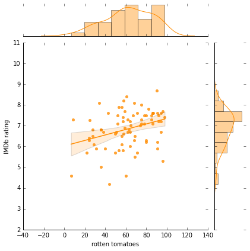

```python
sns.jointplot('rotten tomatoes', 'IMDb rating', data=renewalData, kind='reg',
             color='#FF8C00');
```

The above plot shows that the polynomial regression can be the solution to this prediction problem. A validation curve can help us in order to find the best degree of polynomial.

```python
def PolynomialRegression(degree=5, **kwargs):
    return make_pipeline(PolynomialFeatures(degree), LinearRegression(**kwargs))

x, y = renewalData.iloc[:, 2:3].values, renewalData.iloc[:, 1:2].values
```

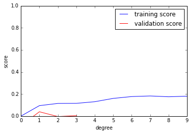

```python
degree = np.arange(0, 10)
train_score, test_score = validation_curve(
    PolynomialRegression(), x, y, 'polynomialfeatures__degree', degree, cv=2)

plt.plot(degree, np.median(train_score, 1),
         color='blue', label='training score')
plt.plot(degree, np.median(test_score, 1),
         color='red', label='validation score')

plt.legend(loc='best')
plt.ylim(0, 1)
plt.xlabel('degree')
plt.ylabel('score');
```

Based on the validation curve, linear regression is the best model, although the score shows that this model is not accurate enough. Both scores are low and it is likely that the model is underfitting. This means either the model is too simple or it is informed by too few features.

```python
reg_linear = LinearRegression()
model_linear = reg_linear.fit(x, y)
y_predict = model_linear.predict(x)
print(f'intercept = {model_linear.intercept_}',
      '\n', f'slope = {model_linear.coef_}')
```

```
intercept = [6.0216786]
 slope = [[0.0132447]]
```

If the equation of the line is: 𝑌=𝛽𝑋+𝜖, then 𝛽 = 0.0132 and 𝜖 = 6.0217

To visualize it:

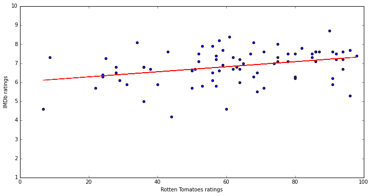

```python
plt.figure(figsize=(12, 6))
plt.scatter(x, y)
plt.plot(x, y_predict, 'r')
plt.xlabel('Rotten Tomatoes ratings')
plt.ylabel('IMDb ratings')
plt.xlim([0, 100])
plt.ylim([1, 10])
plt.show()
```

```python
mse_linear = mean_squared_error (y,y_predict)
print('MSE: ',mse_linear)
r2_linear = r2_score (y,y_predict)
print('R2: ',r2_linear)
```

```
MSE:  0.7164740621474608
R2:  0.10979713636873778
```

The lower the MSE, the higher the accuracy of the prediction model so although this linear model is the best regression model, it is not accurate enough. Removing the outliers may help to increase accuracy.

One way to look for outliers is the box plot:

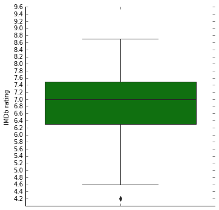

```python
sns.catplot(data=renewalData, y='IMDb rating', kind='box',
            palette=sns.color_palette(['green']))
plt.yticks(np.arange(min(y), max(y)+1, 0.2));
```

The image below shows how a box plot indicates the outliers [(Source of the image)](https://www.simplypsychology.org/boxplots.html#:~:text=Box%20plots%20are%20useful%20as%20they%20show%20outliers%20within%20a,whiskers%20of%20the%20box%20plot.)

[figure not shown]

```python
renewalData_revised = renewalData.drop(renewalData[renewalData['IMDb rating'] < 4.6].index);
```

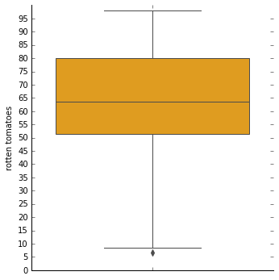

```python
sns.catplot(data=renewalData_revised, y='rotten tomatoes', kind='box',
            palette=sns.color_palette(['orange']))
plt.yticks(np.arange(0, 100, 5));
```

```python
renewalData_revised = renewalData.drop(renewalData[renewalData['rotten tomatoes'] < 10].index);
renewalData_revised
```

|  | title | IMDb rating | rotten tomatoes | Season2 |
| --- | --- | --- | --- | --- |
| 0 | THE FIX | 6.5 | 56.0 | no |
| 1 | SINGLE PARENTS | 7.1 | 75.0 | yes |
| 2 | THE ROOKIE | 8.1 | 68.0 | yes |
| 3 | REL | 4.2 | 44.0 | no |
| 4 | GRAND HOTEL | 7.0 | 74.0 | no |
| ... | ... | ... | ... | ... |
| 74 | see | 7.6 | 43.0 | yes |
| 75 | Mythic Quest | 7.6 | 94.0 | yes |
| 76 | Ted Lasso | 8.7 | 90.0 | yes |
| 77 | Central Park | 6.7 | 94.0 | yes |
| 78 | Home Before Dark | 7.5 | 80.0 | yes |

77 rows × 4 columns

```python
#creating regression model with revised data-set
x, y = renewalData_revised.iloc[:, 2:3].values, renewalData_revised.iloc[:, 1:2].values
```

```python
degree = np.arange(0, 10)
train_score, test_score = validation_curve(
    PolynomialRegression(), x, y, 'polynomialfeatures__degree', degree, cv=2)

reg_linear = LinearRegression()
model_linear = reg_linear.fit(x, y)
y_predict = model_linear.predict(x)
print(f'intercept = {model_linear.intercept_}',
      '\n', f'slope = {model_linear.coef_}')
```

```
intercept = [6.067794]
 slope = [[0.01259211]]
```

```python
mse_linear = mean_squared_error (y,y_predict)
print('MSE: ',mse_linear)
r2_linear = r2_score (y,y_predict)
print('R2: ',r2_linear)
```

```
MSE:  0.6876407048019321
R2:  0.09155277852556876
```

### Predicting renewal for the second season

The goal of this step is predicting the renewal for the second season based on IMDb and Rotten Tomatoes ratings of the first season.

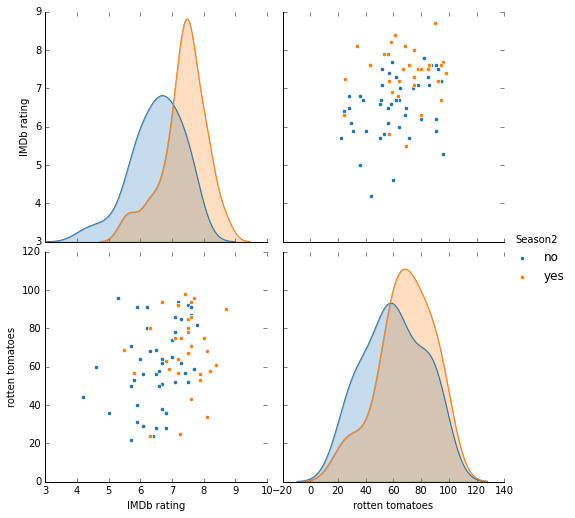

```python
sns.pairplot(renewalData_revised, hue='Season2', size=3.5, palette='tab10');
```

This prediction problem is a supervised classification case in which there is two classes:

1. yes (the show gets a second season)
2. no (the show is canceled after one season)

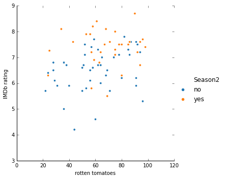

```python
sns.relplot(x='rotten tomatoes', y='IMDb rating', hue='Season2', data=renewalData_revised, palette='tab10');
```

Another column named **2nd** will be added to current data frame, in order to attribute numerical values to **Season 2** feature, 0 means no and 1 means yes.

```python
renewalData_revised['2nd'] = 0
renewalData_revised['2nd'] = np.where(
    renewalData_revised['Season2'] == 'yes', 1, renewalData_revised['2nd'])
renewalData_revised.head(5)
```

|  | title | IMDb rating | rotten tomatoes | Season2 | 2nd |
| --- | --- | --- | --- | --- | --- |
| 0 | THE FIX | 6.5 | 56.0 | no | 0 |
| 1 | SINGLE PARENTS | 7.1 | 75.0 | yes | 1 |
| 2 | THE ROOKIE | 8.1 | 68.0 | yes | 1 |
| 3 | REL | 4.2 | 44.0 | no | 0 |
| 4 | GRAND HOTEL | 7.0 | 74.0 | no | 0 |

The first method that predicts renewal for the second season is **Support Vector Machine**. Since the prediction is based on IMDb rating and Rotten Tomatoes ratings, these two features will be attributed to X and 2nd feature to y. After that, data will be split into the training and testing sets. 40% of the data will be allocated to testing.

```python
X, y = renewalData_revised.iloc[:, 1:3].values, renewalData_revised.iloc[:, 4:].values
X_train, X_test, y_train, y_test = train_test_split(
    X, y, test_size=0.4, random_state=109)
```

The first model is a linear SVC. Since the hardness of the margin is controlled by **C**, this parameter will affect the accuracy of the prediction model.

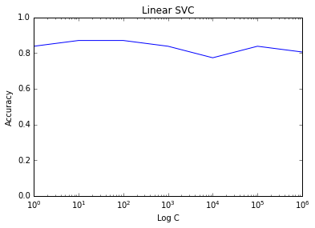

```python
I = [1, 10, 100, 1e3, 1e4, 1e5, 1e6]
C_list_linear = []
Accuracy_list_linear = []
for i in I:
    svm_linear = SVC(kernel='linear', C=i)
    svm_linear.fit(X_train, y_train)
    y_pred = svm_linear.predict(X_test)
    C_list_linear.append(i)
    Accuracy_list_linear.append(metrics.accuracy_score(y_test, y_pred))
plt.xlim([1, 1e6])
plt.ylim([0, 1])
plt.xlabel("Log C")
plt.ylabel("Accuracy")
plt.title('Linear SVC')
plt.xscale('log')
plt.plot(C_list_linear, Accuracy_list_linear);
```

```python
Max_Accuracy_linear = max(Accuracy_list_linear)
Max_Accuracy_index_linear = Accuracy_list_linear.index(Max_Accuracy_linear)
print('Best C: ', C_list_linear[Max_Accuracy_index_linear],
      '\n', 'Accuracy: ', Max_Accuracy_linear)
```

```
Best C:  10
 Accuracy:  0.8709677419354839
```

```python
svm_linear = SVC(kernel='linear', C=C_list_linear[Max_Accuracy_index_linear])
svm_linear.fit(X, y);
```

```python
def plot_svc_decision_function(model, ax=None, plot_support=True):
    if ax is None:
        ax = plt.gca()
    xlim = ax.get_xlim()
    ylim = ax.get_ylim()
    x = np.linspace(xlim[0], xlim[1], 30)
    y = np.linspace(ylim[0], ylim[1], 30)
    Y, X = np.meshgrid(y, x)
    xy = np.vstack([X.ravel(), Y.ravel()]).T
    P = model.decision_function(xy).reshape(X.shape)
    ax.contour(X, Y,
               P,
               colors='k',
               levels=[-1, 0, 1], alpha=0.5,
               linestyles=['--', '-', '--'])
```

[figure not shown]

```python
plt.xlabel("IMDb rating")
plt.ylabel("Rotten Tomatos rating")
plt.scatter(X[:, 0], X[:, 1], c=y, s=50, cmap='viridis')
plot_svc_decision_function(svm_linear);
```

Two other kinds of SVM will be looked at:

1. Radial Basis Function (RBF)
2. polynomial kernel function (poly)

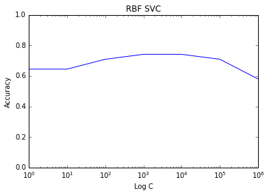

```python
C_list_rbf = []
Accuracy_list_rbf = []
for i in I:
    svm_rbf = SVC(kernel='rbf', C=i)
    svm_rbf.fit(X_train, y_train)
    y_pred = svm_rbf.predict(X_test)
    C_list_rbf.append(i)
    Accuracy_list_rbf.append(metrics.accuracy_score(y_test, y_pred))
plt.xlim([1, 1e6])
plt.ylim([0, 1])
plt.xlabel("Log C")
plt.ylabel("Accuracy")
plt.title('RBF SVC')
plt.xscale('log')
plt.plot(C_list_rbf, Accuracy_list_rbf);
```

```python
Max_Accuracy_rbf = max(Accuracy_list_rbf)
Max_Accuracy_index_rbf = Accuracy_list_rbf.index(Max_Accuracy_rbf)
print('Best C: ', C_list_rbf[Max_Accuracy_index_rbf],
      '\n', 'Accuracy: ', Max_Accuracy_rbf)
```

```
Best C:  1000.0
 Accuracy:  0.7419354838709677
```

```python
svm_rbf = SVC(kernel='rbf', C=C_list_rbf[Max_Accuracy_index_rbf])
svm_rbf.fit(X, y);
```

[figure not shown]

```python
plt.xlabel("IMDb rating")
plt.ylabel("Rotten Tomatos rating")
plt.scatter(X[:, 0], X[:, 1], c=y, s=50, cmap='viridis')
plot_svc_decision_function(svm_rbf);
```

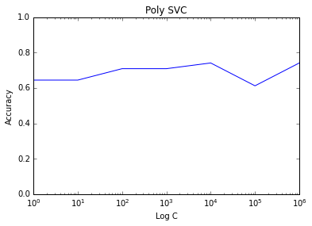

```python
C_list_poly = []
Accuracy_list_poly = []
for i in I:
    svm_poly = SVC(kernel='poly', C=i)
    svm_poly.fit(X_train, y_train)
    y_pred = svm_poly.predict(X_test)
    C_list_poly.append(i)
    Accuracy_list_poly.append(metrics.accuracy_score(y_test, y_pred))
plt.xlim([1, 1e6])
plt.ylim([0, 1])
plt.xlabel("Log C")
plt.ylabel("Accuracy")
plt.title('Poly SVC')
plt.xscale('log')
plt.plot(C_list_poly, Accuracy_list_poly);
```

```python
Max_Accuracy_poly = max(Accuracy_list_poly)
Max_Accuracy_index_poly = Accuracy_list_poly.index(Max_Accuracy_poly)
print('Best C: ', C_list_poly[Max_Accuracy_index_poly],
      '\n', 'Accuracy: ', Max_Accuracy_poly)
```

```
Best C:  10000.0
 Accuracy:  0.7419354838709677
```

```python
svm_poly = SVC(kernel='poly', C=C_list_poly[Max_Accuracy_index_poly])
svm_poly.fit(X, y);
```

[figure not shown]

```python
plt.xlabel("IMDb rating")
plt.ylabel("Rotten Tomatos rating")
plt.scatter(X[:, 0], X[:, 1], c=y, s=50, cmap='viridis')
plot_svc_decision_function(svm_poly);
```

The linear model is more accurate than the others.

```python
y_predict = svm_rbf.predict(X)
renewalData_revised['2nd_predicted'] = y_predict
renewalData_revised
```

|  | title | IMDb rating | rotten tomatoes | Season2 | 2nd | 2nd_predicted |
| --- | --- | --- | --- | --- | --- | --- |
| 0 | THE FIX | 6.5 | 56.0 | no | 0 | 0 |
| 1 | SINGLE PARENTS | 7.1 | 75.0 | yes | 1 | 1 |
| 2 | THE ROOKIE | 8.1 | 68.0 | yes | 1 | 1 |
| 3 | REL | 4.2 | 44.0 | no | 0 | 0 |
| 4 | GRAND HOTEL | 7.0 | 74.0 | no | 0 | 1 |
| ... | ... | ... | ... | ... | ... | ... |
| 74 | see | 7.6 | 43.0 | yes | 1 | 0 |
| 75 | Mythic Quest | 7.6 | 94.0 | yes | 1 | 1 |
| 76 | Ted Lasso | 8.7 | 90.0 | yes | 1 | 1 |
| 77 | Central Park | 6.7 | 94.0 | yes | 1 | 0 |
| 78 | Home Before Dark | 7.5 | 80.0 | yes | 1 | 1 |

77 rows × 6 columns

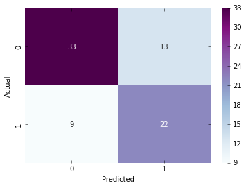

```python
confusion_matrix = pd.crosstab(renewalData_revised['2nd'], renewalData_revised['2nd_predicted'], rownames=[
                               'Actual'], colnames=['Predicted'])
sns.heatmap(confusion_matrix, annot=True, cmap="BuPu")
plt.show()
```

### New data-set

In next step, both of these prediction models will apply to a larger set of data.

```python
file_path_4 = 'renewalData_2.csv'
renewalData_2 = pd.read_csv(file_path_4)
renewalData_2['2nd'] = 0
renewalData_2['2nd'] = np.where(
    renewalData_2['Season2'] == 'no', 0, renewalData_2['2nd'])
renewalData_2['2nd'] = np.where(
    renewalData_2['Season2'] == 'yes', 1, renewalData_2['2nd'])
renewalData_2
```

|  | title | IMDb rating | rotten tomatoes | Season2 | 2nd |
| --- | --- | --- | --- | --- | --- |
| 0 | 12 Dates of Christmas | 6.3 | 52.0 | yes | 1 |
| 1 | 68 Whiskey | 5.5 | 88.0 | no | 0 |
| 2 | 9-1-1: Lone Star | 6.6 | 73.0 | yes | 1 |
| 3 | A Black Lady Sketch Show | 7.1 | 100.0 | yes | 1 |
| 4 | A Little Late Night with Lilly Singh | 1.6 | 82.0 | yes | 1 |
| ... | ... | ... | ... | ... | ... |
| 153 | WHISKEY CAVALIER | 7.1 | 78.0 | no | 0 |
| 154 | Why Women Kill | 8.3 | 67.0 | yes | 1 |
| 155 | Woke | 6.3 | 76.0 | yes | 1 |
| 156 | Work in Progress | 7.1 | 100.0 | yes | 1 |
| 157 | Zoey's Extraordinary Playlist | 8.2 | 76.0 | yes | 1 |

158 rows × 5 columns

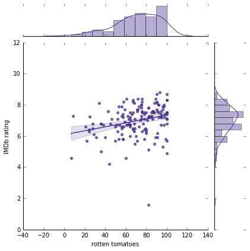

```python
sns.jointplot('rotten tomatoes', 'IMDb rating', data=renewalData_2, kind='reg',
              color="#49358f");
```

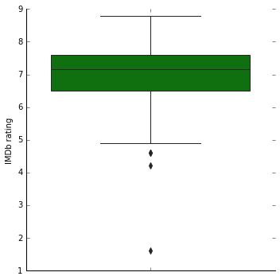

```python
sns.catplot(data=renewalData_2, y='IMDb rating', kind='box',
            palette=sns.color_palette(['green']));
```

```python
renewalData_2_revised = renewalData_2.drop(renewalData_2[renewalData_2['IMDb rating'] < 5].index);
renewalData_2_revised
```

|  | title | IMDb rating | rotten tomatoes | Season2 | 2nd |
| --- | --- | --- | --- | --- | --- |
| 0 | 12 Dates of Christmas | 6.3 | 52.0 | yes | 1 |
| 1 | 68 Whiskey | 5.5 | 88.0 | no | 0 |
| 2 | 9-1-1: Lone Star | 6.6 | 73.0 | yes | 1 |
| 3 | A Black Lady Sketch Show | 7.1 | 100.0 | yes | 1 |
| 5 | A MILLION LITTLE THINGS | 7.9 | 53.0 | yes | 1 |
| ... | ... | ... | ... | ... | ... |
| 153 | WHISKEY CAVALIER | 7.1 | 78.0 | no | 0 |
| 154 | Why Women Kill | 8.3 | 67.0 | yes | 1 |
| 155 | Woke | 6.3 | 76.0 | yes | 1 |
| 156 | Work in Progress | 7.1 | 100.0 | yes | 1 |
| 157 | Zoey's Extraordinary Playlist | 8.2 | 76.0 | yes | 1 |

153 rows × 5 columns

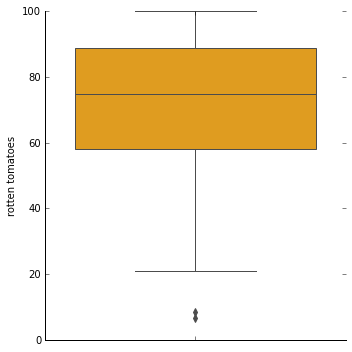

```python
sns.catplot(data=renewalData_2, y='rotten tomatoes', kind='box',
            palette=sns.color_palette(['orange']));
```

```python
renewalData_2_revised = renewalData_2_revised.drop(
    renewalData_2_revised[renewalData_2_revised['rotten tomatoes'] < 20].index)
renewalData_2_revised
```

|  | title | IMDb rating | rotten tomatoes | Season2 | 2nd |
| --- | --- | --- | --- | --- | --- |
| 0 | 12 Dates of Christmas | 6.3 | 52.0 | yes | 1 |
| 1 | 68 Whiskey | 5.5 | 88.0 | no | 0 |
| 2 | 9-1-1: Lone Star | 6.6 | 73.0 | yes | 1 |
| 3 | A Black Lady Sketch Show | 7.1 | 100.0 | yes | 1 |
| 5 | A MILLION LITTLE THINGS | 7.9 | 53.0 | yes | 1 |
| ... | ... | ... | ... | ... | ... |
| 153 | WHISKEY CAVALIER | 7.1 | 78.0 | no | 0 |
| 154 | Why Women Kill | 8.3 | 67.0 | yes | 1 |
| 155 | Woke | 6.3 | 76.0 | yes | 1 |
| 156 | Work in Progress | 7.1 | 100.0 | yes | 1 |
| 157 | Zoey's Extraordinary Playlist | 8.2 | 76.0 | yes | 1 |

152 rows × 5 columns

### Predicting viewers' level of interest based on critics' rating for new data-set

```python
param_grid = {'polynomialfeatures__degree': np.arange(21),
              'linearregression__fit_intercept': [True, False],
              'linearregression__normalize': [True, False]}
grid = GridSearchCV(PolynomialRegression(), param_grid, cv=7)
```

```python
x, y = renewalData_2_revised.iloc[:,
                                  2:3].values, renewalData_2_revised.iloc[:, 1:2].values
x_train, x_test, y_train, y_test = train_test_split(
    x, y, test_size=0.4, random_state=109)

grid.fit(x, y)
grid.best_params_
model = grid.best_estimator_
reg_model = model.fit(x, y)
y_predict = reg_model.predict(x)

mse_linear = mean_squared_error(y, y_predict)
print('MSE: ', mse_linear)
r2_linear = r2_score(y, y_predict)
print('R2: ', r2_linear)
```

```
MSE:  0.5851820459787552
R2:  0.10056797407183382
```

### Predicting renewal for the second season for new data-set

```python
X, y = renewalData_2_revised.iloc[:, 1:3].values, renewalData_2_revised.iloc[:, 4:].values
X_train, X_test, y_train, y_test = train_test_split(
    X, y, test_size=0.4, random_state=109)
```

```python
C = 1
svm_line = SVC(kernel='linear', C=C)
svm_rbf = SVC(kernel='rbf', C=C)
svm_poly = SVC(kernel='poly', C=C)
svm_list = [svm_line,svm_rbf,svm_poly]
svm_name = ['linear','rbf','poly']
```

```python
j = 0
for name in svm_name:
    I = [1, 1e1, 1e2, 1e3, 1e4, 1e5, 1e6, 1e7]
    C_list = []
    Accuracy_list = []
    for i in I:
        svm = SVC(kernel=name, C=i)
        svm.fit(X_train, y_train)
        y_pred = svm.predict(X_test)
        C_list.append(i)
        Accuracy_list.append(metrics.accuracy_score(y_test, y_pred))
    Max_Accuracy = max(Accuracy_list)
    Max_Accuracy_index = Accuracy_list.index(Max_Accuracy)
    print('Best C: ', C_list[Max_Accuracy_index], ' ',
          'Accuracy: ', Max_Accuracy, '(Type:', svm_name[j], ')')
    j += 1
```

```
Best C:  10.0   Accuracy:  0.7377049180327869 (Type: linear )
Best C:  1000000.0   Accuracy:  0.7540983606557377 (Type: rbf )
Best C:  10.0   Accuracy:  0.7213114754098361 (Type: poly )
```

```python
svm_rbf_2 = SVC(kernel='rbf', C=1e6)
svm_rbf_2.fit(X, y);
```

[figure not shown]

```python
plt.xlabel("IMDb rating")
plt.ylabel("Rotten Tomatos rating")
plt.scatter(X[:, 0], X[:, 1], c=y, s=50, cmap='viridis')
plot_svc_decision_function(svm_rbf_2);
```

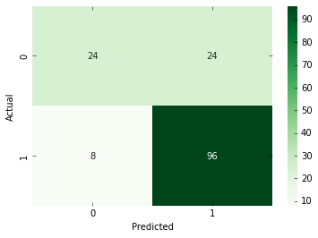

```python
y_predict = svm_rbf_2.predict(X)
renewalData_2_revised['2nd_predicted'] = y_predict
confusion_matrix = pd.crosstab(renewalData_2_revised['2nd'], renewalData_2_revised['2nd_predicted'], rownames=[
                               'Actual'], colnames=['Predicted'])
sns.heatmap(confusion_matrix, annot=True, cmap="Greens")
plt.show()
```

### Decision tree classification

In the last stage of the previous step, the SVM method was used to classify data into two groups: yes and no. Here, we want to build another prediction model that does the exact same classification with a different method, a decision tree. A decision tree is a type of supervised machine learning, a flowchart-like diagram that shows the various outcomes from a series of decisions. It can be used as a decision-making tool, for research analysis, or for planning strategy. [Source](https://www.smartdraw.com/decision-tree/)

```python
# The data
renewalData_DT = renewalData_2 [['title','IMDb rating','rotten tomatoes','Season2','2nd']]
renewalData_DT
```

|  | title | IMDb rating | rotten tomatoes | Season2 | 2nd |
| --- | --- | --- | --- | --- | --- |
| 0 | 12 Dates of Christmas | 6.3 | 52.0 | yes | 1 |
| 1 | 68 Whiskey | 5.5 | 88.0 | no | 0 |
| 2 | 9-1-1: Lone Star | 6.6 | 73.0 | yes | 1 |
| 3 | A Black Lady Sketch Show | 7.1 | 100.0 | yes | 1 |
| 4 | A Little Late Night with Lilly Singh | 1.6 | 82.0 | yes | 1 |
| ... | ... | ... | ... | ... | ... |
| 153 | WHISKEY CAVALIER | 7.1 | 78.0 | no | 0 |
| 154 | Why Women Kill | 8.3 | 67.0 | yes | 1 |
| 155 | Woke | 6.3 | 76.0 | yes | 1 |
| 156 | Work in Progress | 7.1 | 100.0 | yes | 1 |
| 157 | Zoey's Extraordinary Playlist | 8.2 | 76.0 | yes | 1 |

158 rows × 5 columns

```python
#Removing outliers
renewalData_DT_revised = renewalData_DT.drop(
    renewalData_DT[renewalData_DT['IMDb rating'] < 5].index)
renewalData_DT_revised = renewalData_DT_revised.drop(
    renewalData_DT_revised[renewalData_DT_revised['rotten tomatoes'] < 20].index)
renewalData_DT_revised
```

|  | title | IMDb rating | rotten tomatoes | Season2 | 2nd |
| --- | --- | --- | --- | --- | --- |
| 0 | 12 Dates of Christmas | 6.3 | 52.0 | yes | 1 |
| 1 | 68 Whiskey | 5.5 | 88.0 | no | 0 |
| 2 | 9-1-1: Lone Star | 6.6 | 73.0 | yes | 1 |
| 3 | A Black Lady Sketch Show | 7.1 | 100.0 | yes | 1 |
| 5 | A MILLION LITTLE THINGS | 7.9 | 53.0 | yes | 1 |
| ... | ... | ... | ... | ... | ... |
| 153 | WHISKEY CAVALIER | 7.1 | 78.0 | no | 0 |
| 154 | Why Women Kill | 8.3 | 67.0 | yes | 1 |
| 155 | Woke | 6.3 | 76.0 | yes | 1 |
| 156 | Work in Progress | 7.1 | 100.0 | yes | 1 |
| 157 | Zoey's Extraordinary Playlist | 8.2 | 76.0 | yes | 1 |

152 rows × 5 columns

```python
features = ['IMDb rating', 'rotten tomatoes']
X = renewalData_DT_revised[features]
y = renewalData_DT_revised['2nd']
```

```python
X_train, X_test, y_train, y_test = train_test_split(
    X, y, test_size=0.4, random_state=109)
```

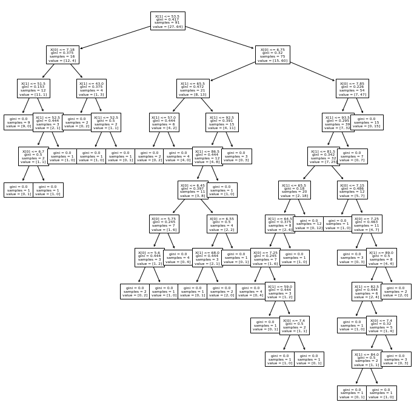

```python
DT_1 = tree.DecisionTreeClassifier()
DT_model = DT_1.fit(X_train, y_train)
plt.figure(figsize=(12, 12))  # set plot size
tree.plot_tree(DT_model, fontsize=6)

plt.savefig('tree_high_dpi', dpi=100)
```

```python
y_predict = DT_model.predict(X_test)
```

```python
metrics.accuracy_score(y_test, y_predict)
```

```
0.6721311475409836
```

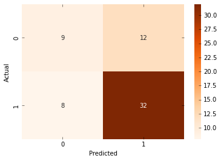

```python
confusion_matrix = pd.crosstab(y_test,y_predict , rownames=[
                               'Actual'], colnames=['Predicted'])
sns.heatmap(confusion_matrix, annot=True, cmap='Oranges')
plt.show()
```

## Conclusion

The initial data-set is a report on an experiment many TV channels do. They gather a randomly selected group of people and show them a short video of an upcoming TV show to know the weakness and strength of it and make some important decisions. The data-set is named **dataFrame** and it has 40 columns and 2939 rows. Each row belongs to a participant in one of the mentioned experiments.

First, the data was explored. Considering the questionnaire and the goal of the project, some columns and rows were removed and missing data and some values were replaced.

The first question that was answered was the level of accuracy. These experiments are designed to predict features related to the shows' future and one of these features is popularity. Therefore, the level of interest that the participants showed was compared to the score people gave the show after watching one season. Less than half of the shows managed to be as popular as the experiment suggested.

The third question asked for a model to predict the people's opinions based on the critics'. people's and critics' opinions are represented by two features: IMDb ratings and Rotten Tomatoes ratings respectively. The obtained model is a linear regression model whose errors are high and not satisfactory. This can be caused because of two reasons:

1. The data points not enough to build a prediction model based on them.
2. It is not possible to predict one of these features based on the other, simply because regular viewers and critics have very different perspectives.

The last question was about the renewal of the shows and was answered by a Support Vector Machine classifier model. The type of kernels that were used are linear, RBF, and polynomial.

```python
file_path_5 = 'Results.csv'
results = pd.read_csv(file_path_5)
results
```

|  | Method | Number of data points | MSE | R2 | Accuracy |
| --- | --- | --- | --- | --- | --- |
| 0 | Regression | 77 | 0.687 | 0.091 | NaN |
| 1 | SVC-Linear | 77 | NaN | NaN | 0.870968 |
| 2 | SVC-RBF | 77 | NaN | NaN | 0.741935 |
| 3 | SVC-Polynomial | 77 | NaN | NaN | 0.741935 |
| 4 | Regression | 152 | 0.585 | 0.100 | NaN |
| 5 | SVC-Linear | 152 | NaN | NaN | 0.737000 |
| 6 | SVC-RBF | 152 | NaN | NaN | 0.754000 |
| 7 | SVC-Polynomial | 152 | NaN | NaN | 0.721000 |

```python
results_reg = results.drop(results[results.Method != 'Regression'].index);
results_reg
```

|  | Method | Number of data points | MSE | R2 | Accuracy |
| --- | --- | --- | --- | --- | --- |
| 0 | Regression | 77 | 0.687 | 0.091 | NaN |
| 4 | Regression | 152 | 0.585 | 0.100 | NaN |

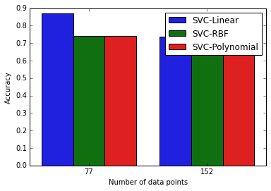

```python
results_SVC = results.drop(results[results.Method == 'Regression'].index);
sns.barplot(x=str('Number of data points'), y='Accuracy', data=results_SVC,hue='Method');
plt.legend(loc='best');
```

There are some ways to improve this project. First of all, more data points will help both the analyze and prediction models. The other thing is considering the effect of each TV show's network on its renewl. There are many different networks out there and every one of them has a unique process for deciding which shows are benefitial enough to have another season.